# *University of Houston Downtown (UHD)*

Quang Le

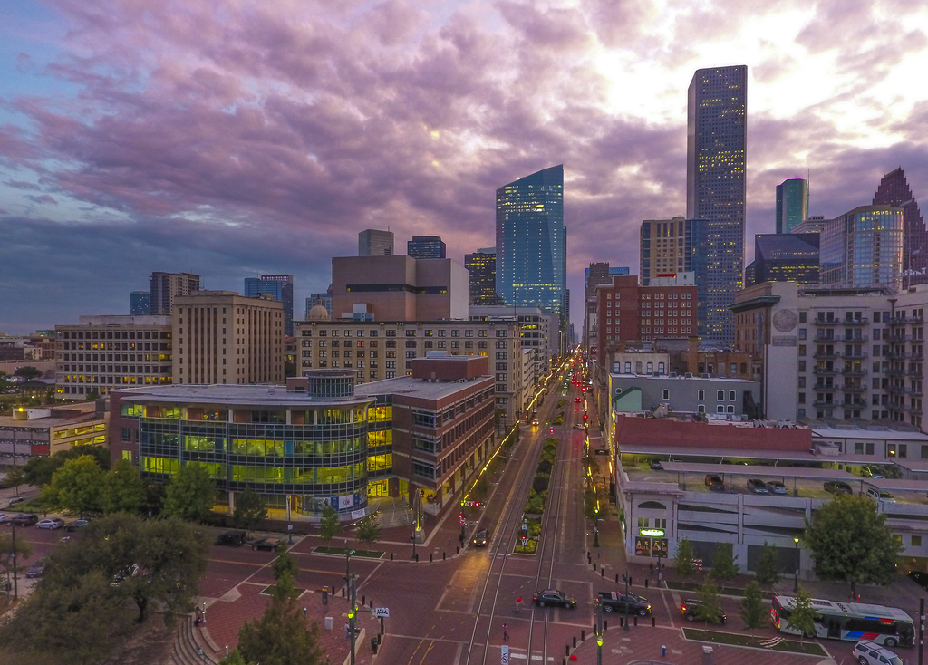

# **Policies & Procedures**

12 February, 2025

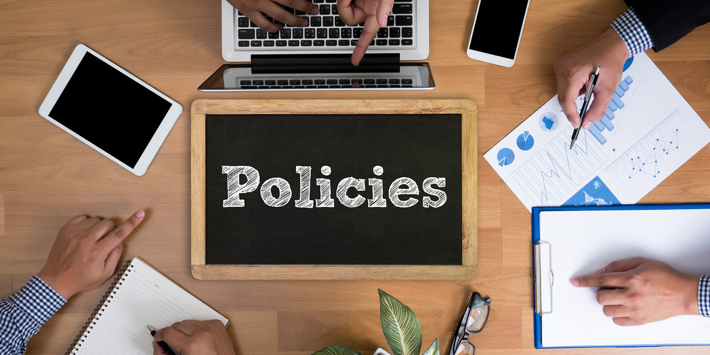

# *I. SI Session Policy & Procedures*

## *1. Before the SI Session*

### *a. You MUST ✓*

1. Bring a *laptop or tablet* (including your charger if possible).
2. Have your *notebook(s) or laptop* ready to take notes.
3. Come with *confidence and a positive attitude.*
4. Ensure you have *access to any relevant course materials*.
5. Be *on time and prepared to engage actively* in the session.
6. All of students joining *VIRTUAL SI SESSION REQUIRED TO OPEN THEIR WEBCAM*.

### *b. You MUST NOT ❌*

1. Bring *harmful objects* (e.g., knife, sword, gun, etc.).
2. Bring *hot food* **(if you want to eat hot food, please consume it outside the session. However, I will allow you to eat if you share your food with me and other students!**

   😁 😍
3. Come with *angry or upset feelings.*

## *2. During SI Session*

1. *Distract others* with side conversations or unrelated activities.
2. Use your device for *non-session-related activities.*
3. *Disrupt the session* by arriving late or leaving early without prior notice.
4. Be *disrespectful or dismissive* towards others’ contributions.
5. Bring any *food or drink* that may cause a distraction or mess **(it is will be OKAY if you share your food/drink with students too! I will very happy with that!)**

   😁 👌

## *3. Emergency Situation during SI Session*

> *IF YOU SEE SOMETHING, SAY SOMETHING!*

### *You MUST ✓*

1. If you feel *not well or ill*, please *inform immediately to SI Leader about your situation.*
2. If *the room has smoke or fire*, please *inform immediately to SI Leader or UHDPD (UHD Police Department) or dial 911*.
3. If you *see suspicious activities* during SI Session, please *inform immediately to SI Leader or UHDPD or dial 911*.

[Next Page →](https://quangnhatm1.github.io/https-quangnhatm1.github.io-activities/)

[←Previous Page](https://quangnhatm1.github.io/https-quangnhatm1.github.io-forms/)

[figure not shown]

© 2025 Quang Le | [University of Houston - Downtown](https://www.uhd.edu) | [Supplemental Instruction Program|](https://www.uhd.edu/sssl/supplemental-instruction/index.aspx)